# Wolt_DataAnalysis_ChiNguyen

## Data Wrangling

```python
# import necessary libraries
import datetime as dt
import pandas as pd
import json

import seaborn as sns
import matplotlib.pyplot as plt
import squarify
import numpy as np
import matplotlib.dates as mdates
```

```python
# load dataset
df = pd.read_csv("dataset_for_datascience_assignment.csv")
pd.options.display.max_columns = None
df.head()
```

|  | REGISTRATION_DATE | REGISTRATION_COUNTRY | PURCHASE_COUNT | PURCHASE_COUNT_DELIVERY | PURCHASE_COUNT_TAKEAWAY | FIRST_PURCHASE_DAY | LAST_PURCHASE_DAY | USER_ID | BREAKFAST_PURCHASES | LUNCH_PURCHASES | EVENING_PURCHASES | DINNER_PURCHASES | LATE_NIGHT_PURCHASES | TOTAL_PURCHASES_EUR | DISTINCT_PURCHASE_VENUE_COUNT | MIN_PURCHASE_VALUE_EUR | MAX_PURCHASE_VALUE_EUR | AVG_PURCHASE_VALUE_EUR | PREFERRED_DEVICE | IOS_PURCHASES | WEB_PURCHASES | ANDROID_PURCHASES | PREFERRED_RESTAURANT_TYPES | USER_HAS_VALID_PAYMENT_METHOD | MOST_COMMON_HOUR_OF_THE_DAY_TO_PURCHASE | MOST_COMMON_WEEKDAY_TO_PURCHASE | AVG_DAYS_BETWEEN_PURCHASES | MEDIAN_DAYS_BETWEEN_PURCHASES | AVERAGE_DELIVERY_DISTANCE_KMS | … |
| --- | --- | --- | --- | --- | --- | --- | --- | --- | --- | --- | --- | --- | --- | --- | --- | --- | --- | --- | --- | --- | --- | --- | --- | --- | --- | --- | --- | --- | --- | --- |
| 0 | 2019-09-01 00:00:00.000 | DNK | 0 | NaN | NaN | NaN | NaN | 1 | NaN | NaN | NaN | NaN | NaN | NaN | NaN | NaN | NaN | NaN | ios | NaN | NaN | NaN | NaN | False | NaN | NaN | NaN | NaN | NaN | … |
| 1 | 2019-09-01 00:00:00.000 | FIN | 1 | 1.0 | 0.0 | 2020-09-02 00:00:00.000 | 2020-09-02 00:00:00.000 | 2 | 0.0 | 1.0 | 0.0 | 0.0 | 0.0 | 38.456 | 1.0 | 38.532 | 38.608 | 38.456 | android | 0.0 | 0.0 | 1.0 | NaN | False | 23.0 | 2.0 | NaN | NaN | 6.853 | … |
| 2 | 2019-09-01 00:00:00.000 | DNK | 19 | 19.0 | 0.0 | 2019-12-10 00:00:00.000 | 2020-05-25 00:00:00.000 | 3 | 0.0 | 4.0 | 1.0 | 14.0 | 0.0 | 631.488 | 9.0 | 20.280 | 43.688 | 33.396 | android | 0.0 | 19.0 | 0.0 | NaN | True | 21.0 | 2.0 | 9.0 | 3.0 | 6.559 | … |
| 3 | 2019-09-01 00:00:00.000 | FIN | 0 | NaN | NaN | NaN | NaN | 4 | NaN | NaN | NaN | NaN | NaN | NaN | NaN | NaN | NaN | NaN | android | NaN | NaN | NaN | NaN | False | NaN | NaN | NaN | NaN | NaN | … |
| 4 | 2019-09-01 00:00:00.000 | GRC | 0 | NaN | NaN | NaN | NaN | 5 | NaN | NaN | NaN | NaN | NaN | NaN | NaN | NaN | NaN | NaN | android | NaN | NaN | NaN | NaN | False | NaN | NaN | NaN | NaN | NaN | … |

```python
# get shape of the dataframe
df.shape
```

```
(21983, 30)
```

```python
# Get general info about the dataset
df.info()
```

```
<class 'pandas.core.frame.DataFrame'>
RangeIndex: 21983 entries, 0 to 21982
Data columns (total 30 columns):
 #   Column                                   Non-Null Count  Dtype
---  ------                                   --------------  -----
 0   REGISTRATION_DATE                        21983 non-null  object
 1   REGISTRATION_COUNTRY                     21983 non-null  object
 2   PURCHASE_COUNT                           21983 non-null  int64
 3   PURCHASE_COUNT_DELIVERY                  12028 non-null  float64
 4   PURCHASE_COUNT_TAKEAWAY                  12028 non-null  float64
 5   FIRST_PURCHASE_DAY                       11964 non-null  object
 6   LAST_PURCHASE_DAY                        12027 non-null  object
 7   USER_ID                                  21983 non-null  int64
 8   BREAKFAST_PURCHASES                      12028 non-null  float64
 9   LUNCH_PURCHASES                          12028 non-null  float64
```

[output cut: 22 more lines]

```python
# lower case column names
df.columns = df.columns.str.lower()
```

```python
#convert date type column to the correct type
df[['registration_date', 'first_purchase_day', 'last_purchase_day']] = df[['registration_date', 'first_purchase_day', 'last_purchase_day']].apply(pd.to_datetime, errors='coerce')
```

The dataframe has 21983 rows, which is the same as the total number of user ids. This means each row has a unique value.

```python
#check duplicates
df.duplicated().sum()
```

```
0
```

```python
#check columns with missing values
df.isnull().sum()
```

```
registration_date                              0
registration_country                           0
purchase_count                                 0
purchase_count_delivery                     9955
purchase_count_takeaway                     9955
first_purchase_day                         10019
last_purchase_day                           9956
user_id                                        0
breakfast_purchases                         9955
lunch_purchases                             9955
evening_purchases                           9955
dinner_purchases                            9955
late_night_purchases                        9955
total_purchases_eur                         9955
distinct_purchase_venue_count               9955
min_purchase_value_eur                      9955
max_purchase_value_eur                      9955
avg_purchase_value_eur                      9955
preferred_device                              73
ios_purchases                               9955
web_purchases                               9955
android_purchases                           9955
preferred_restaurant_types                 19289
user_has_valid_payment_method                  0
most_common_hour_of_the_day_to_purchase     9955
most_common_weekday_to_purchase             9955
avg_days_between_purchases                 14151
median_days_between_purchases              14151
average_delivery_distance_kms               9955
purchase_count_by_store_type                   0
dtype: int64
```

Note that many columms have the same 9955 missing values, I guess that these 9955 are users who haven't made any orders. To ensure that, let's look at the purchase_count column. If the purchase count is 0, my assumption is correct.

```python
# Check for missing values among users with zero purchases
df.query("purchase_count == 0").isnull().sum()
```

```
registration_date                             0
registration_country                          0
purchase_count                                0
purchase_count_delivery                    9955
purchase_count_takeaway                    9955
first_purchase_day                         9955
last_purchase_day                          9955
user_id                                       0
breakfast_purchases                        9955
lunch_purchases                            9955
evening_purchases                          9955
dinner_purchases                           9955
late_night_purchases                       9955
total_purchases_eur                        9955
distinct_purchase_venue_count              9955
min_purchase_value_eur                     9955
max_purchase_value_eur                     9955
avg_purchase_value_eur                     9955
preferred_device                             72
ios_purchases                              9955
web_purchases                              9955
android_purchases                          9955
preferred_restaurant_types                 9927
user_has_valid_payment_method                 0
most_common_hour_of_the_day_to_purchase    9955
most_common_weekday_to_purchase            9955
avg_days_between_purchases                 9955
median_days_between_purchases              9955
average_delivery_distance_kms              9955
purchase_count_by_store_type                  0
dtype: int64
```

```python
#investigate missing values in column first_purchase_day
df.query("first_purchase_day.isnull()").groupby("purchase_count").user_id.count().reset_index(name = 'user_counts')
```

|  | purchase_count | user_counts |
| --- | --- | --- |
| 0 | 0 | 9955 |
| 1 | 1 | 29 |
| 2 | 2 | 12 |
| 3 | 3 | 12 |
| 4 | 4 | 2 |
| 5 | 5 | 4 |
| 6 | 12 | 1 |
| 7 | 13 | 2 |
| 8 | 14 | 1 |
| 9 | 20 | 1 |

Some users have made orders during this time frame but first_purchase_day is missing. The majority of these users have not made any orders (9955). 29 users have made only 1 purchase on 1 day so we can replace missing values in first_purchase_day with last_purchase_day. However, we cannot know for sure the first_purchase_day of the rest who have made more than 1 purchase and registration_date differs from last_purchase_day.

```python
print(f"There are {df.query('first_purchase_day.isnull() & registration_date != last_purchase_day & purchase_count > 1').user_id.count()} users with unidentified first_purchase_day")
```

```
There are 34 users with unidentified first_purchase_day
```

```python
# Replace missing first_purchase_day values
df.loc[df.purchase_count == 1, 'first_purchase_day'] = df["last_purchase_day"]
```

```python
#investigate one user with missing last purchase day
df.query("last_purchase_day.isnull() & purchase_count_delivery.notnull()")
```

|  | registration_date | registration_country | purchase_count | purchase_count_delivery | purchase_count_takeaway | first_purchase_day | last_purchase_day | user_id | breakfast_purchases | lunch_purchases | evening_purchases | dinner_purchases | late_night_purchases | total_purchases_eur | distinct_purchase_venue_count | min_purchase_value_eur | max_purchase_value_eur | avg_purchase_value_eur | preferred_device | ios_purchases | web_purchases | android_purchases | preferred_restaurant_types | user_has_valid_payment_method | most_common_hour_of_the_day_to_purchase | most_common_weekday_to_purchase | avg_days_between_purchases | median_days_between_purchases | average_delivery_distance_kms | … |
| --- | --- | --- | --- | --- | --- | --- | --- | --- | --- | --- | --- | --- | --- | --- | --- | --- | --- | --- | --- | --- | --- | --- | --- | --- | --- | --- | --- | --- | --- | --- |
| 20978 | 2019-09-29 | FIN | 1 | 1.0 | 0.0 | NaT | NaT | 20979 | 0.0 | 1.0 | 0.0 | 0.0 | 0.0 | 38.456 | 1.0 | 38.532 | 38.608 | 38.456 | ios | 1.0 | 0.0 | 0.0 | NaN | False | 3.0 | 6.0 | NaN | NaN | 5.087 | … |

This user made an order but does not have any entries for purchase day.

```python
#investigate avg_days_between_purchases
df.query("avg_days_between_purchases.notnull() & purchase_count == 1 & first_purchase_day == last_purchase_day").avg_days_between_purchases.unique()
```

```
array([], dtype=float64)
```

replace missing values of median_days_between_purchases and avg_days_between_purchases with 0 if first_purchase_day and last_purchase_day are on the same days

```python
# replace missing values in median_days_between_purchases and avg_days_between_purchases with 0
# if first_purchase_day and last_purchase_day are on the same days
df.loc[(df.median_days_between_purchases.isnull()) & (df.first_purchase_day == df.last_purchase_day), 'median_days_between_purchases'] = 0
df.loc[(df.avg_days_between_purchases.isnull()) & (df.first_purchase_day == df.last_purchase_day), 'avg_days_between_purchases'] = 0
```

```python
# create a new column to calculate the difference between first and last purchase day
df['date_diff'] = (df['last_purchase_day'] - df['first_purchase_day']).dt.days
```

```python
# clean column purchase_count_by_store_type
df['purchase_count_by_store_type'].unique()[:2]
```

```
array(['{\n  "General merchandise": 0,\n  "Grocery": 0,\n  "Pet supplies": 0,\n  "Restaurant": 0,\n  "Retail store": 0\n}',
       '{\n  "General merchandise": 0,\n  "Grocery": 0,\n  "Pet supplies": 0,\n  "Restaurant": 1,\n  "Retail store": 0\n}'],
      dtype=object)
```

```python
# explode value in the purchase_count_by_store_type column
df['purchase_count_by_store_type'] = df['purchase_count_by_store_type'].apply(json.loads)
expanded = pd.json_normalize(df['purchase_count_by_store_type'])

# Concatenate back to original df
df = df.drop(columns='purchase_count_by_store_type').join(expanded)
df.head()
```

|  | registration_date | registration_country | purchase_count | purchase_count_delivery | purchase_count_takeaway | first_purchase_day | last_purchase_day | user_id | breakfast_purchases | lunch_purchases | evening_purchases | dinner_purchases | late_night_purchases | total_purchases_eur | distinct_purchase_venue_count | min_purchase_value_eur | max_purchase_value_eur | avg_purchase_value_eur | preferred_device | ios_purchases | web_purchases | android_purchases | preferred_restaurant_types | user_has_valid_payment_method | most_common_hour_of_the_day_to_purchase | most_common_weekday_to_purchase | avg_days_between_purchases | median_days_between_purchases | average_delivery_distance_kms | … |
| --- | --- | --- | --- | --- | --- | --- | --- | --- | --- | --- | --- | --- | --- | --- | --- | --- | --- | --- | --- | --- | --- | --- | --- | --- | --- | --- | --- | --- | --- | --- |
| 0 | 2019-09-01 | DNK | 0 | NaN | NaN | NaT | NaT | 1 | NaN | NaN | NaN | NaN | NaN | NaN | NaN | NaN | NaN | NaN | ios | NaN | NaN | NaN | NaN | False | NaN | NaN | NaN | NaN | NaN | … |
| 1 | 2019-09-01 | FIN | 1 | 1.0 | 0.0 | 2020-09-02 | 2020-09-02 | 2 | 0.0 | 1.0 | 0.0 | 0.0 | 0.0 | 38.456 | 1.0 | 38.532 | 38.608 | 38.456 | android | 0.0 | 0.0 | 1.0 | NaN | False | 23.0 | 2.0 | 0.0 | 0.0 | 6.853 | … |
| 2 | 2019-09-01 | DNK | 19 | 19.0 | 0.0 | 2019-12-10 | 2020-05-25 | 3 | 0.0 | 4.0 | 1.0 | 14.0 | 0.0 | 631.488 | 9.0 | 20.280 | 43.688 | 33.396 | android | 0.0 | 19.0 | 0.0 | NaN | True | 21.0 | 2.0 | 9.0 | 3.0 | 6.559 | … |
| 3 | 2019-09-01 | FIN | 0 | NaN | NaN | NaT | NaT | 4 | NaN | NaN | NaN | NaN | NaN | NaN | NaN | NaN | NaN | NaN | android | NaN | NaN | NaN | NaN | False | NaN | NaN | NaN | NaN | NaN | … |
| 4 | 2019-09-01 | GRC | 0 | NaN | NaN | NaT | NaT | 5 | NaN | NaN | NaN | NaN | NaN | NaN | NaN | NaN | NaN | NaN | android | NaN | NaN | NaN | NaN | False | NaN | NaN | NaN | NaN | NaN | … |

```python
#rename new columns
df.rename(columns={'General merchandise': 'general_merchandise',
                   'Grocery':'grocery',
                   'Pet supplies': 'pet_supplies',
                   'Restaurant': 'restaurant',
                   'Retail store': 'retail_store'
                  }, inplace=True)
```

```python
#Display the first 5 unique values in the 'preferred_restaurant_types' column
#to get a quick overview of customer restaurant preferences
df['preferred_restaurant_types'].unique()[:5]
```

```
array([nan, '[\n  "american"\n]', '[\n  "japanese"\n]',
       '[\n  "italian"\n]', '[\n  "middle eastern"\n]'], dtype=object)
```

```python
# Clean the 'preferred_restaurant_types' column by removing square brackets, newlines, and quotes, then strip whitespace
df['preferred_restaurant_types'] = (
    df['preferred_restaurant_types']
    .str.replace(r'[\[\]\n\r"]+', '', regex=True)
    .str.strip()
)
```

# Data Exploration

## Some Relevant Metrics

```python
# Activation rate
print(f"The activation rate during September 2019 to October 2020 is {round(df.query('purchase_count > 0').user_id.count()/df.user_id.count()*100, 2)} %, indicating that over half of registered users have made at least one order — this is a healthy sign of initial user engagement.")
```

```
The activation rate during September 2019 to October 2020 is 54.72 %, indicating that over half of registered users have made at least one order — this is a healthy sign of initial user engagement.
```

```python
# Churn rate during this period September 2019 to October 2020
print(f"The cumulative churn rate over the entire dataset is {round(df.query('purchase_count == 1').user_id.count()/df.query('purchase_count > 0').user_id.count()*100,2)}%. This means that about one-third of users who placed an order only did so once and did not return. For Wolt, this highlights a key opportunity to improve early retention strategies—such as follow-up offers, better first-time experiences, or loyalty incentives—to turn one-time buyers into repeat customers.")
```

[output not shown]

```python
# Repeat rate
print(f"The repeat rate is {round(df.query('purchase_count > 1').user_id.count()/df.query('purchase_count > 0').user_id.count()*100,2)} %, meaning users who ordered once came back for more, which indicates solid user retention and satisfaction.")
```

```
The repeat rate is 65.26 %, meaning users who ordered once came back for more, which indicates solid user retention and satisfaction.
```

```python
# Cross-Service Adoption Rate, concluded from Cross service usage distribution section
print(f"The cross-service adoption rate is 28%, which indicates that over a quarter of active users engage with more than one Wolt service, showing strong potential for deeper user engagement. This highlights both customer trust and an opportunity to drive growth by promoting multi-service usage. ")
```

```
The cross-service adoption rate is 28%, which indicates that over a quarter of active users engage with more than one Wolt service, showing strong potential for deeper user engagement. This highlights both customer trust and an opportunity to drive growth by promoting multi-service usage.
```

## Data Visualization

```python
#Create a copy dataframe to work with
df_copy = df.copy()
#Exclude users without purchase
df_copy = df_copy.query("purchase_count >= 1")
# Reset index after excluding entries
df_copy = df_copy.reset_index(drop = True)
df_copy.head()
```

|  | registration_date | registration_country | purchase_count | purchase_count_delivery | purchase_count_takeaway | first_purchase_day | last_purchase_day | user_id | breakfast_purchases | lunch_purchases | evening_purchases | dinner_purchases | late_night_purchases | total_purchases_eur | distinct_purchase_venue_count | min_purchase_value_eur | max_purchase_value_eur | avg_purchase_value_eur | preferred_device | ios_purchases | web_purchases | android_purchases | preferred_restaurant_types | user_has_valid_payment_method | most_common_hour_of_the_day_to_purchase | most_common_weekday_to_purchase | avg_days_between_purchases | median_days_between_purchases | average_delivery_distance_kms | … |
| --- | --- | --- | --- | --- | --- | --- | --- | --- | --- | --- | --- | --- | --- | --- | --- | --- | --- | --- | --- | --- | --- | --- | --- | --- | --- | --- | --- | --- | --- | --- |
| 0 | 2019-09-01 | FIN | 1 | 1.0 | 0.0 | 2020-09-02 | 2020-09-02 | 2 | 0.0 | 1.0 | 0.0 | 0.0 | 0.0 | 38.456 | 1.0 | 38.532 | 38.608 | 38.456 | android | 0.0 | 0.0 | 1.0 | NaN | False | 23.0 | 2.0 | 0.0 | 0.0 | 6.853 | … |
| 1 | 2019-09-01 | DNK | 19 | 19.0 | 0.0 | 2019-12-10 | 2020-05-25 | 3 | 0.0 | 4.0 | 1.0 | 14.0 | 0.0 | 631.488 | 9.0 | 20.280 | 43.688 | 33.396 | android | 0.0 | 19.0 | 0.0 | NaN | True | 21.0 | 2.0 | 9.0 | 3.0 | 6.559 | … |
| 2 | 2019-09-01 | FIN | 1 | 1.0 | 0.0 | 2020-10-14 | 2020-10-14 | 8 | 0.0 | 0.0 | 1.0 | 0.0 | 0.0 | 19.228 | 1.0 | 19.266 | 19.304 | 19.228 | android | 0.0 | 0.0 | 1.0 | NaN | True | 5.0 | 1.0 | 0.0 | 0.0 | 1.251 | … |
| 3 | 2019-09-01 | FIN | 19 | 19.0 | 0.0 | 2020-04-18 | 2020-10-27 | 13 | 0.0 | 8.0 | 0.0 | 11.0 | 0.0 | 587.972 | 3.0 | 19.266 | 47.752 | 31.372 | ios | 19.0 | 0.0 | 0.0 | NaN | True | 7.0 | 3.0 | 11.0 | 9.0 | 3.303 | … |
| 4 | 2019-09-01 | FIN | 2 | 2.0 | 0.0 | 2020-08-21 | 2020-09-09 | 14 | 0.0 | 1.0 | 1.0 | 0.0 | 0.0 | 118.404 | 1.0 | 57.798 | 60.960 | 59.708 | ios | 0.0 | 0.0 | 2.0 | american | False | 5.0 | 6.0 | 19.0 | 19.0 | 1.382 | … |

## Customer Engagement Overview

```python
# create a new column that specifies users who have or have not made orders
df['made_orders'] = np.where(df['purchase_count'] == 0, 'Made no order', 'Made orders')
```

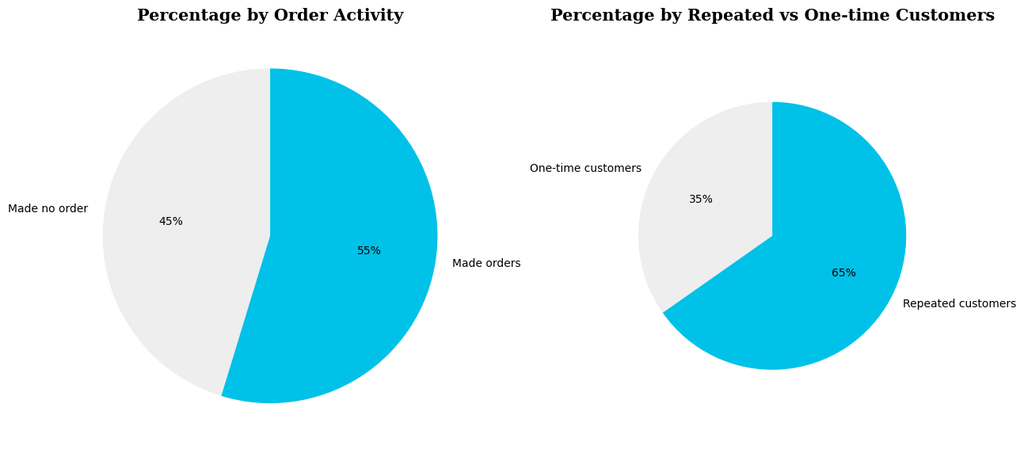

```python
# visualize percentages of users who have made vs. haven't made any orders
user_portion = (
    df
    .groupby('made_orders')
    .agg(user_count = ("user_id", "count"))
)
# Plot pie chart
fig, (ax1, ax2) = plt.subplots(1, 2, figsize = (15, 12))

ax1.pie(
    x = user_portion.user_count,
    labels = user_portion.index,
    startangle = 90,
    autopct= '%.0f%%',
    colors = ['#eeeeee', '#00C1E8'],
)

ax1.set_title("Percentage by Order Activity", fontfamily = 'serif', weight = 'bold', fontsize = 15)


df_copy['repeated_customers'] = np.where(df_copy['purchase_count'] > 1, 'Repeated customers', 'One-time customers')
# visualize percentages of users who have made vs. haven't made any orders
repeated_customer_df = (
    df_copy
    .groupby('repeated_customers')
    .agg(user_count = ("user_id", "count"))
)
# Plot pie chart
ax2.pie(
    x = repeated_customer_df.user_count,
    labels = repeated_customer_df.index,
    startangle = 90,
    autopct= '%.0f%%',
    colors = ['#eeeeee', '#00C1E8'],
    radius = 0.8
)

ax2.set_title("Percentage by Repeated vs One-time Customers", fontfamily = 'serif', weight = 'bold', fontsize = 15)
plt.show()
```

Chart insight: Over half of users (55%) have placed at least one order, indicating solid initial engagement, while 45% remain inactive—highlighting a need for activation strategies. Among those who ordered, 65% are repeat customers, showing a healthy retention rate and suggesting that once users convert, they tend to stick. For a business like Wolt, this emphasizes the importance of optimizing the onboarding experience and first-order incentives to activate new users and convert them into long-term, high-value customers. I will exclude entries of users who made no order during the analysis process.

## Cross-Service Usage Distribution

```python
#Calculate number of users by services
service_user = []

for col in df_copy.columns[30:35]:
    filtered_df = df_copy[df_copy[col] > 0]

# Use the column name as the key in agg
    col_result = filtered_df.agg(**{f"{col}": ("user_id", "count")})

    service_user.append(col_result)

# Combine into a DataFrame
service_user_df = pd.concat(service_user)
service_user_df = service_user_df.sort_values('user_id', ascending = False)
service_user_df
```

|  | user_id |
| --- | --- |
| restaurant | 12028 |
| retail_store | 1857 |
| grocery | 1617 |
| general_merchandise | 1442 |
| pet_supplies | 175 |

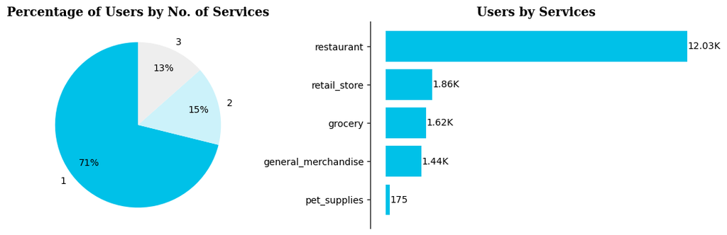

```python
# Create a new column that counts total number of services users have used
df_copy["service_count"]= (df_copy[df_copy.columns[30:35]] > 0).sum(axis=1)
service_df = (
    df_copy
    .groupby('service_count')
    .agg(user_count = ("user_id", "count"))
)
# Plot pie chart
fig, (ax1, ax2) = plt.subplots(1,2, figsize = (14,4))

ax1.pie(
    x = service_df.sort_values('user_count',ascending=False).user_count,
    startangle = 90,
    labels = service_df.sort_values('user_count',ascending=False).index,
    autopct='%.0f%%',
    pctdistance = .75,
    colors = ['#eeeeee', '#ccf2fa', '#00C1E8'][::-1],
)

donut_hole = plt.Circle((0,0), 0.50, fc = 'white')
fig = plt.gcf()

fig.gca().add_artist(donut_hole)
ax1.set_title('Percentage of Users by No. of Services',  fontfamily = 'serif', weight = 'bold', fontsize = 13)

ax2.barh(service_user_df.index[::-1], service_user_df.user_id[::-1], color = '#00C1E8' )
ax2.set_title('Users by Services', fontfamily = 'serif', weight = 'bold', fontsize = 13)

ax2.spines[["top", "right", "bottom"]].set_visible(False)
ax2.set_xticks([])
ax2.set_xlabel("")

# Adding Value Labels
for container in ax2.containers:
    labels = []
    for bar in container:
        value = bar.get_width()
        if value >= 1_000:
            label = f"{value / 1_000:.2f}K"
        else:
            label = f"{value:.0f}"
        labels.append(label)

    ax2.bar_label(container, labels=labels, label_type='edge')
plt.show()
```

Chart insight: The majority of users (71%) engage with only one service, indicating limited cross-service adoption. Restaurants dominate usage with over 12K users, confirming it as the core driver of user engagement. Other services like retail, grocery, and general merchandise see moderate traction, while pet supplies remain largely underutilized. Only 13% of users access three services, highlighting an opportunity to expand multi-service usage. For a platform like Wolt, this suggests strong potential for cross-promotional strategies to increase service adoption and user lifetime value.

## Top 10 Countries by Revenue

```python
revenue_byCountry = (
    df_copy
    .groupby("registration_country")
    .agg(total_revenue = ("total_purchases_eur", "sum"))
).nlargest(10, "total_revenue")
revenue_byCountry
```

| registration_country | total_revenue |
| --- | --- |
| DNK | 1028537.092 |
| FIN | 933584.168 |
| GRC | 150036.084 |
| EST | 2062.456 |
| CZE | 1133.440 |
| NOR | 1023.132 |
| LVA | 974.556 |
| ISR | 372.416 |
| LTU | 327.888 |
| GBR | 302.588 |

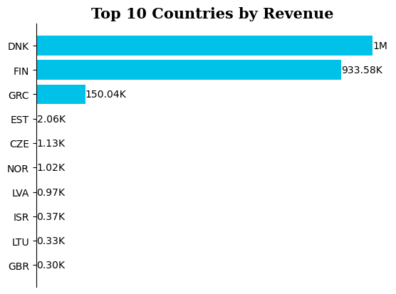

```python
# top 10 total revenue by countries
revenue_byCountry = (
    df_copy
    .groupby("registration_country")
    .agg(total_revenue = ("total_purchases_eur", "sum"))
).nlargest(10, "total_revenue")

fig, ax = plt.subplots()

ax.barh(revenue_byCountry.index[::-1], revenue_byCountry.total_revenue[::-1], color = "#00C1E8")
ax.set_title('Top 10 Countries by Revenue', fontfamily = 'serif', weight = 'bold', fontsize = 15)
ax.set_xlabel('Revenue')
ax.spines[["top", "right", "bottom"]].set_visible(False)
ax.set_xticks([])
ax.set_xlabel("")
# Adding Value Labels
for container in ax.containers:
    labels = []
    for bar in container:
        value = bar.get_width()
        if value >= 1_000_000:
            label = f"{value / 1_000_000:.0f}M"
        else:
            label = f"{value / 1_000:.2f}K"
        labels.append(label)

    ax.bar_label(container, labels=labels, label_type='edge')
plt.show()
```

Chart Insight: In conclusion, the chart identifies the top 10 countries by revenue for Wolt, with Denmark and Finland as the leading markets. Other countries show smaller contributions, indicating potential areas for expansion. Localized strategies can help scale in other regions.

## Percentages of Orders by Meals

```python
order_byMeal = df_copy.loc[:, ['breakfast_purchases', 'lunch_purchases', 'evening_purchases','dinner_purchases']].sum().reset_index(name = 'orders').rename(columns = {"index": "meal"}).sort_values("orders", ascending = False)
order_byMeal
```

|  | meal | orders |
| --- | --- | --- |
| 3 | dinner_purchases | 36433.0 |
| 1 | lunch_purchases | 28567.0 |
| 2 | evening_purchases | 5935.0 |
| 0 | breakfast_purchases | 2333.0 |

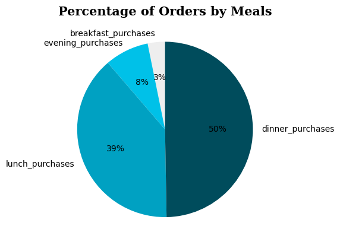

```python
#Calculate percentage orders by meals
order_byMeal = df_copy.loc[:, ['breakfast_purchases', 'lunch_purchases', 'evening_purchases','dinner_purchases']].sum().reset_index(name = 'orders').rename(columns = {"index": "meal"}).sort_values("orders", ascending = False)
# Plot pie chart
fig, ax = plt.subplots()

ax.pie(
    x = order_byMeal.orders[::-1],
    labels = order_byMeal.meal[::-1],
    startangle = 90,
    autopct= '%.0f%%',
    colors = ['#004C5C', '#00A1C2', '#00C1E8','#eeeeee', ][::-1]
)

ax.set_title("Percentage of Orders by Meals", fontfamily = 'serif', weight = 'bold', fontsize = 15)
plt.show()
```

Chart insight: The chart illustrates the distribution of Wolt's orders by meal type, with dinner purchases dominating as the largest segment, followed by lunch purchases. Breakfast and evening purchases represent smaller portions, highlighting dinner as the primary focus for Wolt's order volume. Marketing breakfast or lunch deals could diversify revenue streams and attract users during off-peak times.

## Avg. Purchase Value by Devices

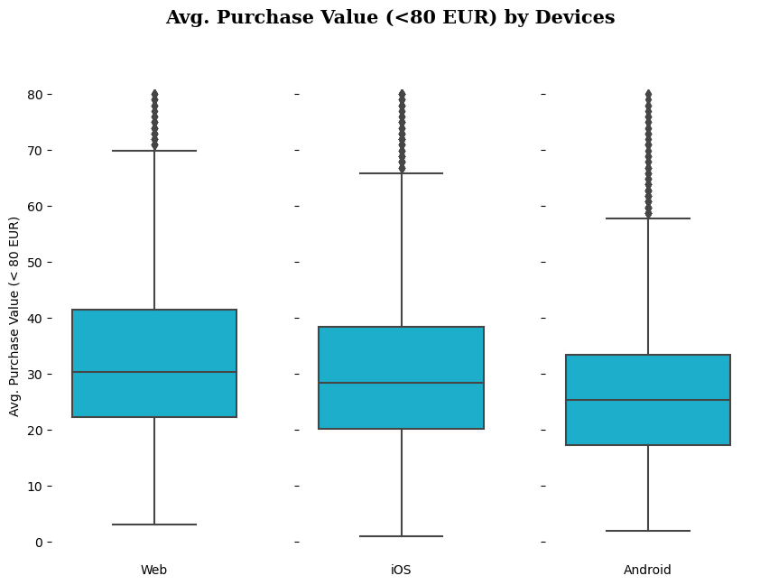

```python
import matplotlib.pyplot as plt
import seaborn as sns

# Create a figure with 1 row and 3 columns of subplots, sharing the Y-axis
fig, (ax1, ax2, ax3) = plt.subplots(1, 3, sharey=True, figsize=(10, 7))

# === Web Boxplot ===
sns.boxplot(
    data=df_copy.query('web_purchases > 0 & avg_purchase_value_eur < 80'),  # Filter for Web purchases
    y='avg_purchase_value_eur',
    ax=ax1,
    color='#00C1E8'
)
ax1.spines[['top', 'right', 'left', 'bottom']].set_visible(False)  # Hide all spines for a minimalist look
ax1.set_xticks([])  # Hide x-axis ticks
ax1.set_ylabel("Avg. Purchase Value (< 80 EUR)")  # No Y-label (shared from ax1)
ax1.set_xlabel("Web")  # Label x-axis

# Remove x-axis ticks on the second plot (ax2)
ax2.set_xticks([])

# === iOS Boxplot ===
sns.boxplot(
    data=df_copy.query('ios_purchases > 0 & avg_purchase_value_eur < 80'),  # Filter for iOS purchases and reasonable avg value
    y='avg_purchase_value_eur',
    ax=ax2,
    color='#00C1E8'
)
ax2.spines[['top', 'right', 'left', 'bottom']].set_visible(False)  # Clean up chart borders
ax2.set_xlabel("iOS")  # Label x-axis
ax2.set_ylabel("")  # Label y-axis

# === Android Boxplot ===
sns.boxplot(
    data=df_copy.query('android_purchases > 0 & avg_purchase_value_eur < 80'),  # Filter for Android purchases
    y='avg_purchase_value_eur',
    ax=ax3,
    color='#00C1E8'
)
ax3.spines[['top', 'right', 'left', 'bottom']].set_visible(False)
ax3.set_xticks([])
ax3.set_ylabel("")
ax3.set_xlabel("Android")

# Remove x-axis ticks and labels from all plots for a cleaner look
for ax in [ax1, ax2, ax3]:
    ax.tick_params(axis='x', which='both', bottom=False, top=False, labelbottom=False)

# Add a common title for all three plots
plt.suptitle("Avg. Purchase Value (<80 EUR) by Devices", fontfamily='serif', weight='bold', fontsize=15)

# Display the plot
plt.show()
```

## Churn Rate & MoM Change

```python
df_test=df_copy.query('last_purchase_day <= "2019-09-30"').user_id.count()
df_test
```

```
2767
```

```python
# Count the total number of unique users
total_user = df_copy.user_id.count()

# Group users by the day of their last purchase and count how many churned each day,
# then resample to monthly frequency to get total monthly churn
churn_df = (
    df
    .groupby('last_purchase_day')
    .agg(monthly_churn=("user_id", "count"))
).resample('M', origin='start').sum()

# Calculate how many users were active at the start of each month
# Subtract cumulative churn from total users, and shift by 1 to get the starting population
churn_df["starting_period"] = (total_user - churn_df["monthly_churn"].cumsum()).shift(1)

# Fill the first month's starting_period with total users (since there's no previous month to shift from)
churn_df["starting_period"].fillna(total_user, inplace=True)

# Calculate monthly churn rate as a percentage of the starting user base
churn_df['churn_rate'] = round(100 * churn_df['monthly_churn'] / churn_df['starting_period'], 2)

# Calculate month-over-month change in churn rate
churn_df['MoM_change'] = round(churn_df["churn_rate"].pct_change() * 100, 2)

# Exclude the last row (e.g. last month) from analysis by replacing it with NaN
# to account for incomplete data at the end of the period
churn_df.iloc[-1, :] = np.nan

churn_df
```

| last_purchase_day | monthly_churn | starting_period | churn_rate | MoM_change |
| --- | --- | --- | --- | --- |
| 2019-09-30 | 2767.0 | 12028.0 | 23.00 | NaN |
| 2019-10-31 | 555.0 | 9261.0 | 5.99 | -73.96 |
| 2019-11-30 | 405.0 | 8706.0 | 4.65 | -22.37 |
| 2019-12-31 | 372.0 | 8301.0 | 4.48 | -3.66 |
| 2020-01-31 | 312.0 | 7929.0 | 3.93 | -12.28 |
| 2020-02-29 | 383.0 | 7617.0 | 5.03 | 27.99 |
| 2020-03-31 | 386.0 | 7234.0 | 5.34 | 6.16 |
| 2020-04-30 | 438.0 | 6848.0 | 6.40 | 19.85 |
| 2020-05-31 | 596.0 | 6410.0 | 9.30 | 45.31 |
| 2020-06-30 | 503.0 | 5814.0 | 8.65 | -6.99 |
| 2020-07-31 | 568.0 | 5311.0 | 10.69 | 23.58 |
| 2020-08-31 | 759.0 | 4743.0 | 16.00 | 49.67 |
| 2020-09-30 | 1098.0 | 3984.0 | 27.56 | 72.25 |
| 2020-10-31 | NaN | NaN | NaN | NaN |

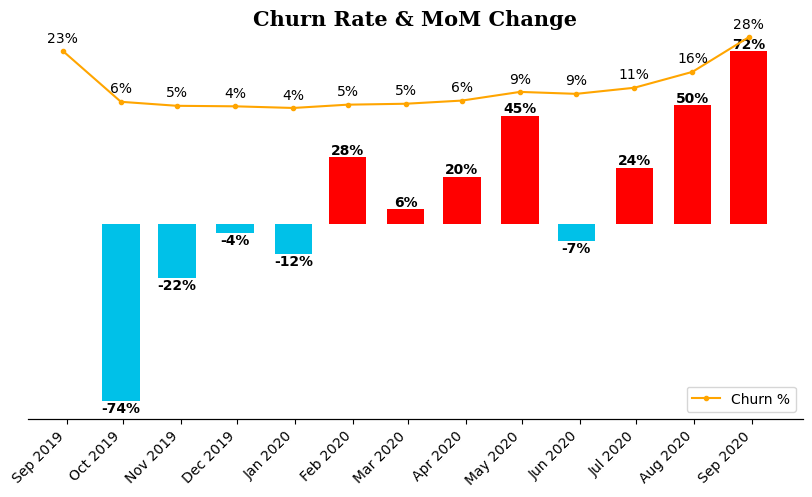

```python
# Create a figure and axis for the chart
fig, ax = plt.subplots(figsize=(10, 5))

# Set bar colors: blue for decrease in churn rate, red for increase
colors = ['#00C1E8' if val < 0 else 'red' for val in churn_df["MoM_change"]]

# Adjust x-axis to reflect the previous month for each data point
month_format = churn_df.index - pd.DateOffset(months=1)

# Plot the Month-over-Month (MoM) churn rate change as bars
bars = ax.bar(month_format, churn_df.MoM_change, width=20, color=colors)

# Add chart title and style
ax.set_title('Churn Rate & MoM Change', fontfamily='serif', weight='bold', fontsize=15)

# Hide unnecessary spines for a cleaner look
ax.spines[['left', 'top', 'right']].set_visible(False)

# Format x-axis to show each month in "Abbreviated Month Year" format
ax.xaxis.set_major_locator(mdates.MonthLocator())
ax.xaxis.set_major_formatter(mdates.DateFormatter('%b %Y'))
plt.setp(ax.get_xticklabels(), rotation=45, ha='right')  # Rotate labels for better readability

# Remove y-ticks from primary y-axis (MoM change)
ax.set_yticks([])

# Add labels on top or bottom of each bar
for bar in bars:
    value = bar.get_height()

    if pd.isna(value) or not pd.api.types.is_number(value):
        continue  # Skip invalid values

    label = f"{value:.0f}%"
    x = bar.get_x() + bar.get_width() / 2
    y = value + (0.05 if value >= 0 else -0.15)  # Offset for label position

    if pd.notna(x) and pd.notna(y):
        ax.text(x, y, label,
                ha='center',
                va='bottom' if value >= 0 else 'top',
                fontweight='bold')

# Create a secondary y-axis to plot churn rate trend
ax2 = ax.twinx()

# Plot churn rate as an orange line with dots
ax2.plot(
    month_format,
    churn_df.churn_rate,
    linewidth=1.5,
    color='orange',
    marker='.',
    label='Churn %'
)

# Annotate churn rate values above each point
for x, y in zip(month_format, churn_df['churn_rate']):
    if pd.notna(x) and pd.notna(y):
        ax2.text(x, y + 3, f"{y:.0f}%", ha='center')

# Set limits and hide secondary y-axis ticks and spines for aesthetics
ax2.set_ylim(-100)
ax2.set_yticks([])
ax2.spines[['left', 'top', 'right']].set_visible(False)

# Add legend to describe the churn % line
ax2.legend(loc='lower right')

# Display the chart
plt.show()
```

Chart Insight: October 2020 represents the final month of the dataset and may contain incomplete data. Therefore, it is excluded from the churn rate calculation to maintain accuracy. Rising churn in certain months may indicate seasonal trends or service issues. Wolt should analyze drop-off reasons (e.g., pricing, delivery delays) and test retention strategies like personalized offers.